# Music Information Retrieval: Part 2

# Audio Features

## Time Domain Features

### Zero Crossing Rate

Zero-crossing rate is a simple, straightforward and inexpensive feature to examine the similarity between two or more accelerometer sensors. It measures whether two sets of time series measurements exhibit similar patters. It is particularly useful to analyze measurements that are corrupted by noise. For example, a measurement with a high zero-crossing rate, i.e., the number of samples per second that cross the zero reference line, indicates that it is noisy. However, we observe that even for sensors having the same orientation, the calibration error results in a deviation of 40s. Substituting the zero-crossing value by a mean valuecrossing, i.e., by defining a mean threshold that serves as a reference, results in a calibration error with a deviation between 2 and 15/s for individual axes and between 0 and 2/s for the absolute acceleration values of the individual measurements. Cross test of uncorrelated measurements, on the other hand, reveals that the overall calibration error is markedly bigger: between 7 and 50/s for the raw measurements and between 5 and 30/s for the absolute values.

The Zero Crossing Rate (ZCR) is defined by:

$zcr = \frac{1}{N-1} \sum_{i=1}^{N-1} | sign|x(i)| - sign|x(i-1)| |$

where $N$ is the number of samples of an audio file and the signum function is defined by:

$sign|x(i)| = \begin{cases} 1, & \text{ if } x(i) > 0\\ 0, & \text{ if } x(i) = 0\\ -1,&\text{ if } x(i) < 0 \end{cases}$

average number of times the audio signal crosses the zero amplitude line per time unit. very simple to compute has been applied to speech processing to distinguish voiced sections from noise

also has been applied to MIR tasks such as classifying percussion sounds Genres

```python
def zero_crossing_rate_BruteForce(wavedata):

    zero_crossings = 0

    for i in range(1, number_of_samples):

        if ( wavedata[i - 1] <  0 and wavedata[i] >  0 ) or \
           ( wavedata[i - 1] >  0 and wavedata[i] <  0 ) or \
           ( wavedata[i - 1] != 0 and wavedata[i] == 0):

                zero_crossings += 1

    zero_crossing_rate = zero_crossings / float(number_of_samples - 1)

    return zero_crossing_rate
```

The following method is numerical more elegant and computationally efficient. It uses the optimized linear algebraic functions of the Numerical Python (numpy) package.

The method further computes the Zero Crossing Rate for a sequence of blocks (also called frames or windows).

```python
def zero_crossing_rate(wavedata, block_length, sample_rate):

    # how many blocks have to be processed?
    num_blocks = int(np.ceil(len(wavedata)/block_length))

    # when do these blocks begin (time in seconds)?
    timestamps = (np.arange(0,num_blocks - 1) * (block_length / float(samplerate)))

    zcr = []

    for i in range(0,num_blocks-1):

        start = i * block_length
        stop  = np.min([(start + block_length - 1), len(wavedata)])

        zc = 0.5 * np.mean(np.abs(np.diff(np.sign(wavedata[start:stop]))))
        zcr.append(zc)

    return np.asarray(zcr), np.asarray(timestamps)
```

The following charts visualize how the Zero Crossing Rate correlates with the audio signal. The upper chart shows the spectrogram of the track. The lower chart superimposes the Zero Crossing Rate over the waveform of the track. It can be observed that sewuences with increased energy in high frequency reagions have a higher zero crossing rate.

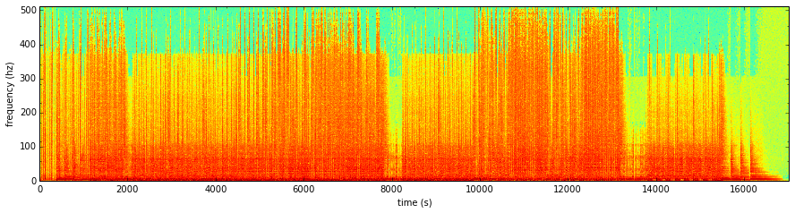

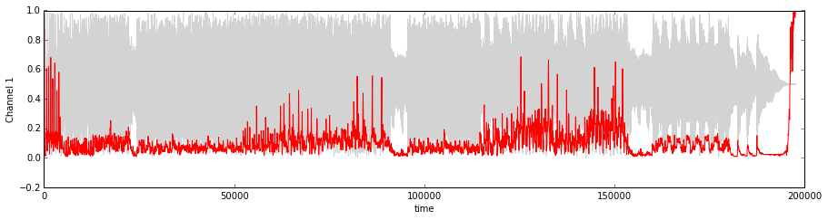

```python
genre = "Rock"

# calculate zero-crossing-rate
zcr, ts = zero_crossing_rate(sound_files[genre]["wavedata"], 2048, sound_files[genre]["samplerate"]);

show_feature_superimposed(genre, zcr, ts);
```

Use ZCR to compare music

```python
# calculate ZCR for all tracks
for genre in sound_files.keys():

    sound_files[genre]["zcr"], _ = zero_crossing_rate(sound_files[genre]["wavedata"],
                                                      2048,
                                                      sound_files[genre]["samplerate"])
```

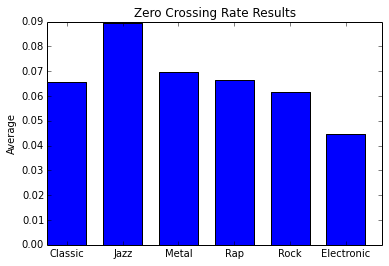

```python
# plot results
plot_compairison(sound_files, "zcr", ["mean"])
```

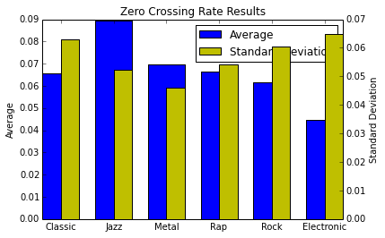

```python
plot_compairison(sound_files, "zcr", ["mean", "std"])
```

### Root Mean Square

Root Mean Square is a way of comparing arbitrary waveforms based upon their equivalent energy. RMS voltage is the contant (DC) voltage that would be required to produce the same heat in a resistive load, indicating equivalent ability to do work. You can't use a simple "average voltage": Consider that a sine wave has positive and negative phases that would average to zero, yet it still generates heat regardless of the polarity of the voltage.

The RMS method takes the square of the instantaneous voltage before averaging, then takes the square root of the average. This solves the polarity problem, since the square of a negative value is the same as the square of a positive value. For a sine wave, the RMS value thus computed is the same as the amplitude (zero-to-peak value) divided by the square root of two, or about 0.7071 of the amplitude. For a repetitive waveform like this, an accurate calculation can be done by averaging over a single cycle of the wave (or an integer number of cycles), but for random noise sources the averaging time must be long enough to get a good representation of the characteristics of the source.

For noise or signal bursts, the RMS value is still the effective heating value, but of course it is reduced because the signal is not always present. If you know the RMS value of the continuous signal, the true RMS of the burst will be the continuous RMS times the square root of the fraction of the time the signal is on.

$r_{rms} = \sqrt{\frac{1}{n} \sum_{i=1}^{n} x_{i}^2}$

```python
def root_mean_square(wavedata, block_length, sample_rate):

    # how many blocks have to be processed?
    num_blocks = int(np.ceil(len(wavedata)/block_length))

    # when do these blocks begin (time in seconds)?
    timestamps = (np.arange(0,num_blocks - 1) * (block_length / float(samplerate)))

    rms = []

    for i in range(0,num_blocks-1):

        start = i * block_length
        stop  = np.min([(start + block_length - 1), len(wavedata)])

        rms_seg = np.sqrt(np.mean(wavedata[start:stop]**2))
        rms.append(rms_seg)

    return np.asarray(rms), np.asarray(timestamps)
```

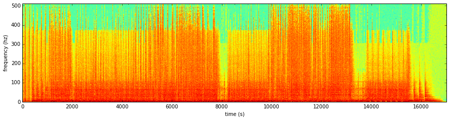

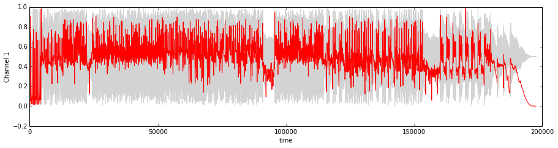

```python
genre = "Rock"

# calculate root-mean-square
rms, ts = root_mean_square(sound_files[genre]["wavedata"], 2048, sound_files[genre]["samplerate"]);

show_feature_superimposed(genre, rms, ts, squared_wf=False);
```

```python
# calculate Zero Crossing Rate for the collection
for genre in sound_files.keys():

    sound_files[genre]["rms"], _ = root_mean_square(sound_files[genre]["wavedata"],
                                                    2048,
                                                    sound_files[genre]["samplerate"])
```

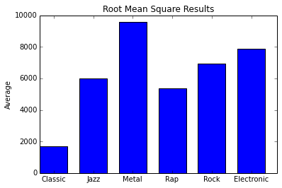

```python
# plot results
plot_compairison(sound_files, "rms", ["mean"])
```

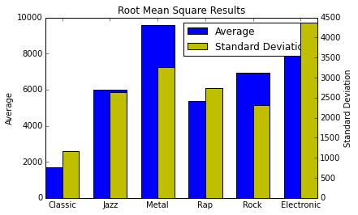

```python
plot_compairison(sound_files, "rms", ["mean", "std"])
```

## Spectral Features

### Spectral Centroid

- center of gravity (balancing point of the spectrum)
- It determines the frequency area around which most of the signal energy concentrates
- gives an indication of how “dark” or “bright” a sound is

The Spectral Centroid $SC$ is the frequency-weighted sum of the power spectrum (=squared Magnitude spectrum $M$) normalized by its unweighted sum:

$SC(t) = \frac{\sum_{n=1}^{N}|M(t,n)|^2 * n}{\sum_{n=1}^{N}|M(t,n)|^2}$

where $t$ represents the current time frame and $n$ is the index for one of $N$ frequency bins calculated by the FFT.

```python
def spectral_centroid(wavedata, window_size, sample_rate):

    magnitude_spectrum = stft(wavedata, window_size)

    timebins, freqbins = np.shape(magnitude_spectrum)

    # when do these blocks begin (time in seconds)?
    timestamps = (np.arange(0,timebins - 1) * (timebins / float(sample_rate)))

    sc = []

    for t in range(timebins-1):

        power_spectrum = np.abs(magnitude_spectrum[t])**2

        sc_t = np.sum(power_spectrum * np.arange(1,freqbins+1)) / np.sum(power_spectrum)

        sc.append(sc_t)


    sc = np.asarray(sc)
    sc = np.nan_to_num(sc)

    return sc, np.asarray(timestamps)
```

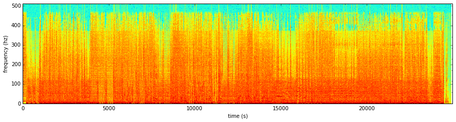

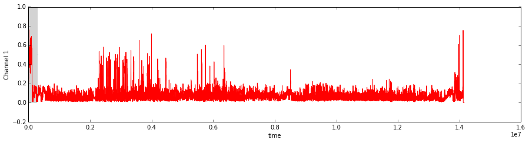

```python
genre = "Metal"

sc, ts = spectral_centroid(sound_files[genre]["wavedata"], 1024, sound_files[genre]["samplerate"])

show_feature_superimposed(genre, sc, ts, squared_wf=False);
```

```python
# calculate Spectral Centroid for the collection
for genre in sound_files.keys():

    sound_files[genre]["sc"], _ = spectral_centroid(sound_files[genre]["wavedata"],
                                                    1024,
                                                    sound_files[genre]["samplerate"])
```

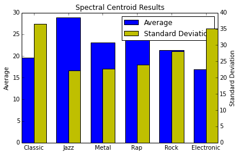

```python
plot_compairison(sound_files, "sc", ["mean", "std"])
```

### Spectral Rolloff

- the frequency below which some fraction, k (typically 0.85, 0.9 or 0.95 percentile), of the cumulative spectral power resides
- measure of the skewness of the spectral shape
- indication of how much energy is in the lower frequencies
- It is used to distinguish voiced from unvoiced speech or music

$\sum_{n=1}^{SR(t)}|M(t,n)|^2 = n* \sum_{n=1}^{N}|M(t,n)|^2$

```python
def spectral_rolloff(wavedata, window_size, sample_rate, k=0.85):

    # convert to frequency domain
    magnitude_spectrum = stft(wavedata, window_size)
    power_spectrum     = np.abs(magnitude_spectrum)**2
    timebins, freqbins = np.shape(magnitude_spectrum)

    # when do these blocks begin (time in seconds)?
    timestamps = (np.arange(0,timebins - 1) * (timebins / float(sample_rate)))

    sr = []

    spectralSum    = np.sum(power_spectrum, axis=1)

    for t in range(timebins-1):

        # find frequency-bin indeces where the cummulative sum of all bins is higher
        # than k-percent of the sum of all bins. Lowest index = Rolloff
        sr_t = np.where(np.cumsum(power_spectrum[t,:]) >= k * spectralSum[t])[0][0]

        sr.append(sr_t)

    sr = np.asarray(sr).astype(float)

    # convert frequency-bin index to frequency in Hz
    sr = (sr / freqbins) * (sample_rate / 2.0)

    return sr, np.asarray(timestamps)
```

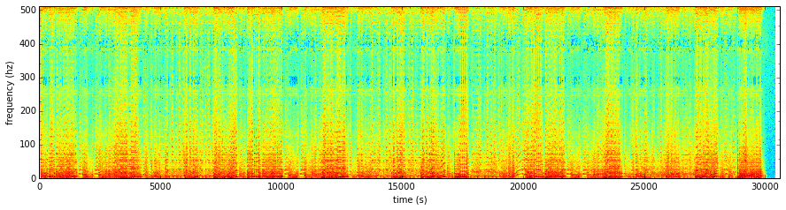

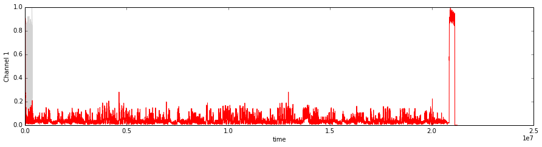

```python
genre = "Classic"

sr, ts = spectral_rolloff(sound_files[genre]["wavedata"],
                           1024,
                           sound_files[genre]["samplerate"],
                           k=0.85)

show_feature_superimposed(genre, sr, ts, squared_wf=False);
```

```python
# calculate Spectral Rolloff for the collection
for genre in sound_files.keys():

    sound_files[genre]["sr"], _ = spectral_rolloff(sound_files[genre]["wavedata"],
                                                   1024,
                                                   sound_files[genre]["samplerate"],
                                                   k=0.85)
```

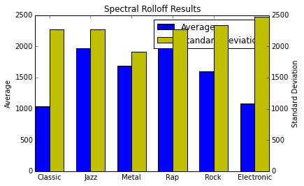

```python
plot_compairison(sound_files, "sr", ["mean", "std"])
```

### Spectral Flux

- squared differences in frequency distribution of two successive time frames
- measures the rate of local change in the spectrum

$SF(t) = \frac{\sqrt{\sum_{n=1}^{N}(|M(t,n)| - |M(t-1,n)|)^2} }{N}$

```python
def spectral_flux(wavedata, window_size, sample_rate):

    # convert to frequency domain
    magnitude_spectrum = stft(wavedata, window_size)
    timebins, freqbins = np.shape(magnitude_spectrum)

    # when do these blocks begin (time in seconds)?
    timestamps = (np.arange(0,timebins - 1) * (timebins / float(sample_rate)))

    sf = np.sqrt(np.sum(np.diff(np.abs(magnitude_spectrum))**2, axis=1)) / freqbins

    return sf[1:], np.asarray(timestamps)
```

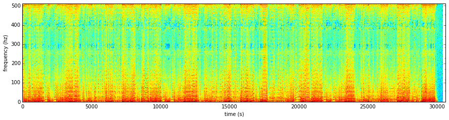

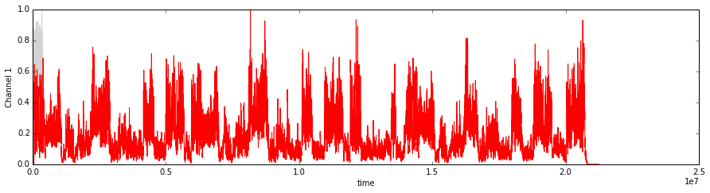

```python
genre = "Classic"

sf, ts = spectral_flux(sound_files[genre]["wavedata"],
                       1024,
                       sound_files[genre]["samplerate"])

show_feature_superimposed(genre, sf, ts);
```

### Spectral Variability

- standard deviation of the bin values of the magnitude spectrum
- provides an indication of how flat the spectrum is and if some frequency regions are much more prominent than others

### Strongest Partial

- center frequency of the bin of the magnitude or power spectrum with the greatest strength
- can provide a primitive form of pitch tracking

### MPEG7 Features

MPEG-7 is a multimedia content description standard defined by the Moving Picture Expert Group aka MPEG.

- **Multimedia Content Description Interface**
- ISO/IEC standard by MPEG (Moving Picture Experts Group)
- Providing meta-data for multimedia
- MPEG-1, -2, -4: make content available
- MPEG-7: makes content accessible, retrievable, filterable, manageable (via device / computer).
- was Adopted in 2002
- Details:
  - ISO/IEC JTC1/SC29/WG11N6828; editor:José M. Martínez Palma de Mallorca, Oct. 2004, MPEG-7 Overview (version 10)
  - http://www.chiariglione.org/mpeg/standards/mpeg-7/mpeg-7.htm
- Specifies
  - Set of audio descriptors
  - a set of Reference Software

**Low-level descriptors:** * spectral, parametric, and temporal features of a signal

**High-level description tools:** * specific to a set of applications * general sound recognition and indexing * instrumental timbre * spoken content * audio signature description scheme * melodic description tools to facilitate query-by-humming

#### MPEG 7 Audio Framework Stack

[figure not shown]

**Basic:** temporally sampled scalar values for general use. * AudioWaveform Descriptor: waveform envelope for display purposes. * AudioPower Descriptor: temporally-smoothed instantaneous power quick summary of a signal. Applicable to all kinds of signals.

**Basic Spectral:** single time-frequency analysis of signal * AudioSpectrumEnvelope: Base class. the short-term power spectrum: display, synthesize, general-purpose search * AudioSpectrumCentroid: is the spectrum dominated by high or low frequencies? * AudioSpectrumSpread: the power spectrum centered near the spectral centroid, or spread out over the spectrum? pure-tone and noise-like sounds * AudioSpectrumFlatness: the presence of tonal components

**Signal Parameters:** periodic or quasi-periodic signals * AudioFundamentalFrequency: “confidence measure”, replacing “pitch-tracking” * AudioHarmonicity: distinction between sounds with a harmonic / inharmonic / non-harmonic spectrum

**Timbral Temporal:** temporal characteristics of segments of sounds, musical timbre * LogAttackTime * TemporalCentroid: where in time the energy of a signal is focused. Useful when attack times are identical

**Timbral Spectral:** spectral features in a linear-frequency space * SpectralCentroid: power-weighted average of the frequency of the bins in the linear power spectrum. distinguishing musical instrument timbres. * 4 Ds for harmonic regularly-spaced components of signals: * HarmonicSpectralCentroid * HarmonicSpectralDeviation * HarmonicSpectralSpread * HarmonicSpectralVariation

**Spectral Basis:** low-dimensional projections of a spectral space to aid compactness and recognition * AudioSpectrumBasis: a series of (time-varying / statistically independent) basis functions derived from the singular value decomposition of a normalized power spectrum. * AudioSpectrumProjection: low-d features of a spectrum after projection upon a reduced rank basis. independent subspaces of a spectra correlate strongly with different sound sources. Provide more salience using less space. With Sound Classification and Indexing Description Tools.

**Silence segment:** no significant sound * aid further segmentation of the audio stream, or as a hint not to process a segment

## Psychoaccoustical Features

### Psychoaccoustics

- psychological (subjective) correlations of the physical parameters of acoustics
  - Humans are most sensitive to sounds in the 1-5 kHz range

### Mel-Frequency Cepstral Coefficients (MFCC)

- used previously in speech recognition
- model human auditory response (Mel scale)
- „cepstrum“ (s-p-e-c reversed): result of taking the Fourier transform (FFT) of the decibel spectrum as if it were a signal
- show rate of change in the different spectrum bands
- Dominant feature in speech recognition, because of ist ability to represent the speech amplitude spectrum in a compact form
- has also prooved to be highly efficient in Music Retrieval
- good timbre feature
- represent the rate of change in the different spectrum bands

#### The Mel-Scale

[figure not shown]

- perceptually motivated scale
- human auditory system does not perceive pitch in linear manner
- Mel comes from the word melody to indicate that the scale is based on pitch comparisons
- maps between actual frequencies and perceived pitch
- was obtained empirically by listening experiments
- reference point:
  - 1000 Hz tone, 40 dB above listener's threshold = 1000 Mels
  - This is the range where humans are most sensitive to variations in sound
- Mapping is approximately
  - linear below 1kHz and
  - logarhitmic above

#### MFCC Computiation

[figure not shown]

1. Pre-processing in time-domain (pre-emphasizing)
2. Compute the spectrum amplitude by windowing with a Hamming window
3. Filter the signal in the spectral domain with a triangular filter-bank, whose filters are approximatively linearly spaced on the mel scale, and have equal bandwith in the mel scale
4. Compute the DCT of the log-spectrum

```python
input_data = sound_files["Classic"]["wavedata"]
```

Apply pre-filtering

```python
# Pre-emphasis filter.

# Parameters
nwin    = 256
nfft    = 1024
fs      = 16000
nceps   = 13

# Pre-emphasis factor (to take into account the -6dB/octave
# rolloff of the radiation at the lips level)
prefac  = 0.97

# MFCC parameters: taken from auditory toolbox
over    = nwin - 160

filtered_data = lfilter([1., -prefac], 1, input_data)
```

Compute the spectrum amplitude by windowing with a Hamming window

```python
windows     = hamming(256, sym=0)
framed_data = segment_axis(filtered_data, nwin, over) * windows

# Compute the spectrum magnitude
magnitude_spectrum = np.abs(fft(framed_data, nfft, axis=-1))
```

Filter the signal in the spectral domain with a triangular filter-bank, whose filters are approximatively linearly spaced on the mel scale, and have equal bandwith in the mel scale

```python
# Compute triangular filterbank for MFCC computation.

lowfreq  = 133.33
linsc    = 200/3.
logsc    = 1.0711703
fs = 44100

nlinfilt = 13
nlogfilt = 27

# Total number of filters
nfilt    = nlinfilt + nlogfilt

#------------------------
# Compute the filter bank
#------------------------
# Compute start/middle/end points of the triangular filters in spectral
# domain
freqs            = np.zeros(nfilt+2)
freqs[:nlinfilt] = lowfreq + np.arange(nlinfilt) * linsc
freqs[nlinfilt:] = freqs[nlinfilt-1] * logsc ** np.arange(1, nlogfilt + 3)
heights          = 2./(freqs[2:] - freqs[0:-2])

# Compute filterbank coeff (in fft domain, in bins)
filterbank  = np.zeros((nfilt, nfft))

# FFT bins (in Hz)
nfreqs = np.arange(nfft) / (1. * nfft) * fs

for i in range(nfilt):

    low = freqs[i]
    cen = freqs[i+1]
    hi  = freqs[i+2]

    lid    = np.arange(np.floor(low * nfft / fs) + 1,
                       np.floor(cen * nfft / fs) + 1, dtype=np.int)

    rid    = np.arange(np.floor(cen * nfft / fs) + 1,
                       np.floor(hi * nfft / fs)  + 1, dtype=np.int)

    lslope = heights[i] / (cen - low)
    rslope = heights[i] / (hi - cen)

    filterbank[i][lid] = lslope * (nfreqs[lid] - low)
    filterbank[i][rid] = rslope * (hi - nfreqs[rid])
```

Filter the spectrum through the triangle filterbank

```python
# apply filter
mspec = np.log10(np.dot(magnitude_spectrum, filterbank.T))
```

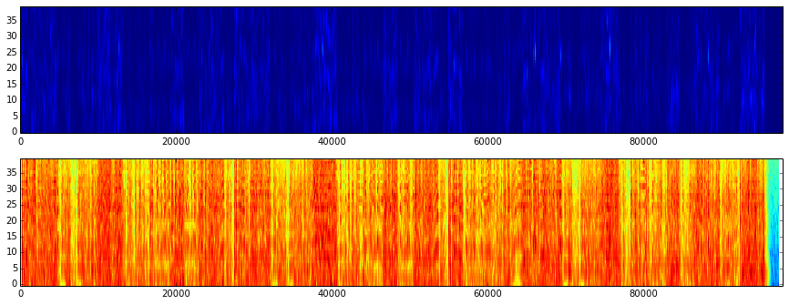

```python
fig, ax = plt.subplots(2, 1, sharey=True, figsize=(PLOT_WIDTH, 5.5))
cax = ax[0].imshow(np.transpose(magnitude_spectrum), origin="lower", aspect="auto",  interpolation="nearest")
cax = ax[1].imshow(np.transpose(mspec), origin="lower", aspect="auto",  interpolation="nearest")
plt.show()
```

Compute the MFCC by computing the DCT of the log-spectrum

```python
# Use the DCT to 'compress' the coefficients (spectrum -> cepstrum domain)
MFCCs = dct(mspec, type=2, norm='ortho', axis=-1)[:, :nceps]
```

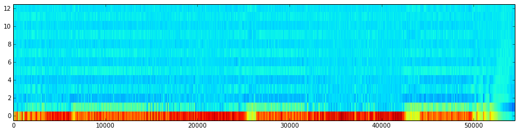

```python
MFCCs, mspec, spec = mfcc(sound_files["Rock"]["wavedata"])

fig, ax = plt.subplots(1, 1, sharey=True, figsize=(PLOT_WIDTH, 3.5))
cax = ax.imshow(np.transpose(MFCCs), origin="lower", aspect="auto",  interpolation="nearest")
plt.show()
```

### Rhythm Patterns

[figure not shown]

Rhythm Patterns (also called Fluctuation Patterns) describe modulation amplitudes for a range of modulation frequencies on "critical bands" of the human auditory range, i.e. fluctuations (or rhythm) on a number of frequency bands. The feature extraction process for the Rhythm Patterns is composed of two stages:

First, the specific loudness sensation in different frequency bands is computed, by using a Short Time FFT, grouping the resulting frequency bands to psycho-acoustically motivated critical-bands, applying spreading functions to account for masking effects and successive transformation into the decibel, Phon and Sone scales. This results in a power spectrum that reflects human loudness sensation (Sonogram).

In the second step, the spectrum is transformed into a time-invariant representation based on the modulation frequency, which is achieved by applying another discrete Fourier transform, resulting in amplitude modulations of the loudness in individual critical bands. These amplitude modulations have different effects on human hearing sensation depending on their frequency, the most significant of which, referred to as fluctuation strength, is most intense at 4 Hz and decreasing towards 15 Hz. From that data, reoccurring patterns in the individual critical bands, resembling rhythm, are extracted, which – after applying Gaussian smoothing to diminish small variations – result in a time-invariant, comparable representation of the rhythmic patterns in the individual critical bands.

### Read Wave File

Read wave file from disk. Only wave input is currently supported. It is intended to leave it that way - the calling application has to take care of the decoding and has to provide pcm data.

```python
data = sound_files["Rock"]["wavedata"]
fs   = sound_files["Rock"]["samplerate"]
```

```python
# Parameters
skip_leadin_fadeout = 1
step_width          = 3

segment_size        = 2**18
fft_window_size     = 1024   # for 44100 Hz

# Pre-calculate required values

duration  =  data.shape[0]/fs

# calculate frequency values on y-axis (for bark scale calculation)
freq_axis = float(fs)/fft_window_size * np.arange(0,(fft_window_size/2) + 1)

# modulation frequency x-axis (after 2nd fft)
mod_freq_res  = 1 / (float(segment_size) / fs) # resolution of modulation
                                               # frequency axis (0.17 Hz)
mod_freq_axis = mod_freq_res * np.arange(257)  # modulation frequencies along
                                               # x-axis from index 1 to 257)

fluct_curve   = 1 / (mod_freq_axis/4 + 4/mod_freq_axis)
```

find position of wave segment

```python
skip_seg = skip_leadin_fadeout

seg_pos = np.array([1, segment_size])

if ((skip_leadin_fadeout > 0) or (step_width > 1)):

    if (duration < 45):

        # if file is too small, don't skip leadin/fadeout and set step_width to 1
        step_width = 1
        skip_seg   = 0

    else:
        seg_pos = seg_pos + segment_size * skip_seg; # advance by number of skip_seg segments (i.e. skip lead_in)

# values verified
```

extract wave segment that will be processed

```python
wavsegment = data[seg_pos[0]-1:seg_pos[1]]
```

adjust hearing threshold

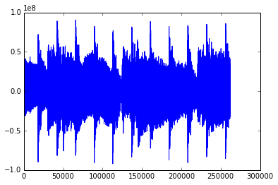

```python
wavsegment = 0.0875 * wavsegment * (2**15)

plot(wavsegment);
```

Convert to frequency domain

```python
# [S1] spectrogram: real FFT with hanning window and 50 % overlap

# number of iterations with 50% overlap
n_iter = wavsegment.shape[0] / fft_window_size * 2 - 1
w      = np.hanning(fft_window_size)

spectrogr = np.zeros((fft_window_size/2 + 1, n_iter))

idx = np.arange(fft_window_size)

# stepping through the wave segment,
# building spectrum for each window
for i in range(n_iter):

    spectrogr[:,i] = periodogram(x=wavsegment[idx], win=w)
    idx = idx + fft_window_size/2
```

```python
Pxx = spectrogr
```

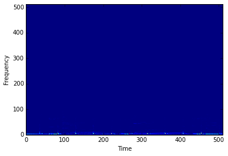

```python
pylab.figure()
pylab.imshow((spectrogr), origin='lower', aspect='auto',interpolation='nearest')
pylab.xlabel('Time')
pylab.ylabel('Frequency')
pylab.show()
```

### Map to Bark Scale

#### Bark Scale

[figure not shown]

- psychoacoustical scale (related to Mel scale)
- proposed by Eberhard Zwicker in 1961
- named after Heinrich Barkhausen who proposed the first subjective measurements of loudness
- 24 „critical bands“ of hearing (non linear)
- a frequency scale on which equal distances correspond with perceptually equal distances
- Associated to mel scale: 1 Bark corresponds to 100 mel

Prepare Bark-filterbanks

```python
# border definitions of the 24 critical bands of hearing
bark = [100,   200,  300,  400,  510,  630,   770,   920,
        1080, 1270, 1480, 1720, 2000, 2320,  2700,  3150,
        3700, 4400, 5300, 6400, 7700, 9500, 12000, 15500]

eq_loudness = np.array(
    [[ 55,   40,  32,  24,  19,  14, 10,  6,  4,  3,  2,
        2,    0,  -2,  -5,  -4,   0,  5, 10, 14, 25, 35],
     [ 66,   52,  43,  37,  32,  27, 23, 21, 20, 20, 20,
       20,   19,  16,  13,  13,  18, 22, 25, 30, 40, 50],
     [ 76,   64,  57,  51,  47,  43, 41, 41, 40, 40, 40,
     39.5, 38,  35,  33,  33,  35, 41, 46, 50, 60, 70],
     [ 89,   79,  74,  70,  66,  63, 61, 60, 60, 60, 60,
       59,   56,  53,  52,  53,  56, 61, 65, 70, 80, 90],
     [103,   96,  92,  88,  85,  83, 81, 80, 80, 80, 80,
       79,   76,  72,  70,  70,  75, 79, 83, 87, 95,105],
     [118,  110, 107, 105, 103, 102,101,100,100,100,100,
       99,   97,  94,  90,  90,  95,100,103,105,108,115]])

loudn_freq = np.array(
    [31.62,   50,  70.7,   100, 141.4,   200, 316.2,  500,
     707.1, 1000,  1414,  1682,  2000,  2515,  3162, 3976,
     5000,  7071, 10000, 11890, 14140, 15500])

# calculate bark-filterbank
loudn_bark = np.zeros((eq_loudness.shape[0], len(bark)))

i = 0
j = 0

for bsi in bark:

    while j < len(loudn_freq) and bsi > loudn_freq[j]:
        j += 1

    j -= 1

    if np.where(loudn_freq == bsi)[0].size != 0: # loudness value for this frequency already exists
        loudn_bark[:,i] = eq_loudness[:,np.where(loudn_freq == bsi)][:,0,0]
    else:
        w1 = 1 / np.abs(loudn_freq[j] - bsi)
        w2 = 1 / np.abs(loudn_freq[j + 1] - bsi)
        loudn_bark[:,i] = (eq_loudness[:,j]*w1 + eq_loudness[:,j+1]*w2) / (w1 + w2)

    i += 1
```

Apply Bark-Filter

```python
matrix = np.zeros((len(bark),Pxx.shape[1]))

barks = bark[:]
barks.insert(0,0)

for i in range(len(barks)-1):

    matrix[i] = np.sum(Pxx[((freq_axis >= barks[i]) & (freq_axis < barks[i+1]))], axis=0)
```

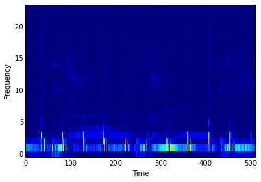

```python
pylab.figure()
pylab.imshow(matrix, origin='lower', aspect='auto',interpolation='nearest')
pylab.xlabel('Time')
pylab.ylabel('Frequency')
pylab.show()
```

### Spectral Masking

- Occlusion of a quiet sound by a louder sound when both sounds are present simultaneously and have similar frequencies
  - Simultaneous masking: two sounds active simultaneously
  - Post-masking: a sound closely following it (100-200 ms)
  - Pre-masking: a sound preceding it (usually neglected, only measured during about 20ms)
- Spreading function defining the influence of the $j$-th critical band on the $i$-th

For Example: * A quiet sound is masked by a loud sound that has the same frequency * if both are played simultaneously * if the are played very close to each other

```python
# SPREADING FUNCTION FOR SPECTRAL MASKING
# CONST_spread contains matrix of spectral frequency masking factors
n_bark_bands = len(bark)

CONST_spread = np.zeros((n_bark_bands,n_bark_bands))

for i in range(n_bark_bands):
    CONST_spread[i,:] = 10**((15.81+7.5*((i-np.arange(n_bark_bands))+0.474)-17.5*(1+((i-np.arange(n_bark_bands))+0.474)**2)**0.5)/10)

spread = CONST_spread[0:matrix.shape[0],:]
matrix = np.dot(spread, matrix)
```

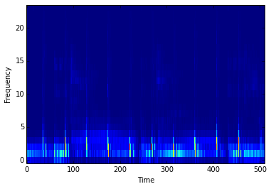

```python
pylab.figure()
pylab.imshow(matrix, origin='lower', aspect='auto',interpolation='nearest')
pylab.xlabel('Time')
pylab.ylabel('Frequency')
pylab.show()
```

### Map to Decibel Scale

Transform the energy values on the critical bands into decibel scale

```python
matrix[np.where(matrix < 1)] = 1

matrix = 10 * np.log10(matrix)
```

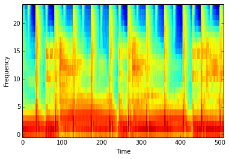

```python
pylab.figure()
pylab.imshow(matrix, origin='lower', aspect='auto',interpolation='nearest')
pylab.xlabel('Time')
pylab.ylabel('Frequency')
pylab.show()
```

### Transform to Phon Scale

#### Equal loudness curves (Phon)

[figure not shown]

- Represents the relationship between the sound pressure level in decibel and the perceived hearing sensation.
- This relationship is not linear and depends on the frequency of the tone
- Centered around 1khz
- equal loudness contours for 3, 20, 40, 60, 80, 100 phon
- To perceive a 40Hz tone with the same sensation sf loudness, 5 times more sound presure is required.

Compute specific loudness sensation per critical band

```python
# phon-mappings
phon = [3, 20, 40, 60, 80, 100, 101]


# number of bark bands, matrix length in time dim
n_bands = matrix.shape[0]
t       = matrix.shape[1]

# DB-TO-PHON BARK-SCALE-LIMIT TABLE
# introducing 1 level more with level(1) being infinite
# to avoid (levels - 1) producing errors like division by 0


table_dim = n_bands;
cbv       = np.concatenate((np.tile(np.inf,(table_dim,1)),
                            loudn_bark[:,0:n_bands].transpose()),1)

phons     = phon[:]
phons.insert(0,0)
phons     = np.asarray(phons)

# init lowest level = 2
levels = np.tile(2,(n_bands,t))

for lev in range(1,6):
    db_thislev = np.tile(np.asarray([cbv[:,lev]]).transpose(),(1,t))
    levels[np.where(matrix > db_thislev)] = lev + 2

# the matrix 'levels' stores the correct Phon level for each datapoint
cbv_ind_hi = np.ravel_multi_index(dims=(table_dim,7), multi_index=np.array([np.tile(np.array([range(0,table_dim)]).transpose(),(1,t)), levels-1]), order='F')
cbv_ind_lo = np.ravel_multi_index(dims=(table_dim,7), multi_index=np.array([np.tile(np.array([range(0,table_dim)]).transpose(),(1,t)), levels-2]), order='F')

# interpolation factor % OPT: pre-calc diff
ifac = (matrix[:,0:t] - cbv.transpose().ravel()[cbv_ind_lo]) / (cbv.transpose().ravel()[cbv_ind_hi] - cbv.transpose().ravel()[cbv_ind_lo])

ifac[np.where(levels==2)] = 1 # keeps the upper phon value;
ifac[np.where(levels==8)] = 1 # keeps the upper phon value;

matrix[:,0:t] = phons.transpose().ravel()[levels - 2] + (ifac * (phons.transpose().ravel()[levels - 1] - phons.transpose().ravel()[levels - 2])) # OPT: pre-calc diff
```

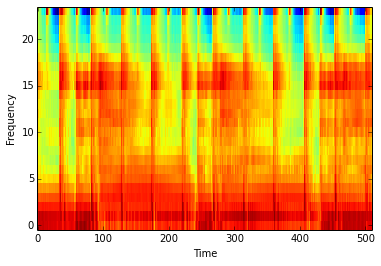

```python
pylab.figure()
pylab.imshow(matrix, origin='lower', aspect='auto',interpolation='nearest')
pylab.xlabel('Time')
pylab.ylabel('Frequency')
pylab.show()
```

### Transform to Sone Scale

#### Sone Transformation

[figure not shown]

- Perceived loudness measured in Phon does not increase linearly
- Transformation into Sone
- Up to 40 phon slow increase in perceived loudness, then drastic increase
- Higher sensibility for certain loudness differences

Sone 1 2 4 8 16 32 64

Phon 40 50 60 70 80 90 100

```python
idx     = np.where(matrix >= 40)
not_idx = np.where(matrix < 40)

matrix[idx]     =  2**((matrix[idx]-40)/10)
matrix[not_idx] =  (matrix[not_idx]/40)**2.642

# values verified
```

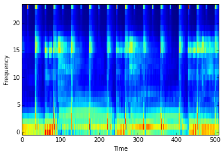

```python
pylab.figure()
pylab.imshow(matrix, origin='lower', aspect='auto',interpolation='nearest')
pylab.xlabel('Time')
pylab.ylabel('Frequency')
pylab.show()
```

## Statistical Spectrum Descriptors

The Sonogram is calculated as in the first part of the Rhythm Patterns calculation. According to the occurrence of beats or other rhythmic variation of energy on a specific critical band, statistical measures are able to describe the audio content. Our goal is to describe the rhythmic content of a piece of audio by computing the following statistical moments on the Sonogram values of each of the critical bands: mean, median, variance, skewness, kurtosis, min- and max-value

```python
def calc_statistical_features(mat):

    result = np.zeros((mat.shape[0],7))

    result[:,0] = np.mean(mat, axis=1)
    result[:,1] = np.var(mat, axis=1)
    result[:,2] = scipy.stats.skew(mat, axis=1)
    result[:,3] = scipy.stats.kurtosis(mat, axis=1)
    result[:,4] = np.median(mat, axis=1)
    result[:,5] = np.min(mat, axis=1)
    result[:,6] = np.max(mat, axis=1)

    result = np.nan_to_num(result)

    return result
```

```python
ssd = calc_statistical_features(matrix)

ssd.shape
```

```
(24L, 7L)
```

## Rhythm Patterns

Calculate fluctuation patterns from scaled spectrum

```python
# calculate fft window-size
fft_size = 2**(nextpow2(matrix.shape[1]))

rhythm_patterns = np.zeros((matrix.shape[0], fft_size), dtype=complex128)

# calculate fourier transform for each bark scale
for b in range(0,matrix.shape[0]):

    rhythm_patterns[b,:] = fft(matrix[b,:], fft_size)

# normalize results
rhythm_patterns = rhythm_patterns / 256

# take first 60 values of fft result including DC component
feature_part_xaxis_rp = range(0,60)

rp = np.abs(rhythm_patterns[:,feature_part_xaxis_rp])
```

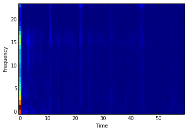

```python
pylab.figure()
pylab.imshow(rp, origin='lower', aspect='auto',interpolation='nearest')
pylab.xlabel('Time')
pylab.ylabel('Frequency')
pylab.show()
```

## Rhythm Histograms

The Rhythm Histogram features we use are a descriptor for general rhythmics in an audio document. Contrary to the Rhythm Patterns and the Statistical Spectrum Descriptor, information is not stored per critical band. Rather, the magnitudes of each modulation frequency bin of all critical bands are summed up, to form a histogram of "rhythmic energy" per modulation frequency. The histogram contains 60 bins which reflect modulation frequency between 0 and 10 Hz. For a given piece of audio, the Rhythm Histogram feature set is calculated by taking the median of the histograms of every 6 second segment processed.

```python
rh = np.sum(np.abs(rhythm_patterns[:,feature_part_xaxis_rp]),axis=0)
```

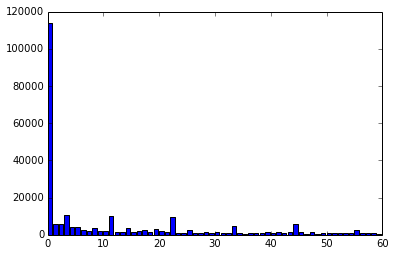

```python
fig, ax = plt.subplots()
ax.bar(range(rh.shape[0]),rh)
plt.show();
```

## Modulation Variance Descriptors

This descriptor measures variations over the critical frequency bands for a specific modulation frequency (derived from a rhythm pattern).

Considering a rhythm pattern, i.e. a matrix representing the amplitudes of 60 modulation frequencies on 24 critical bands, an MVD vector is derived by computing statistical measures (mean, median, variance, skewness, kurtosis, min and max) for each modulation frequency over the 24 bands. A vector is computed for each of the 60 modulation frequencies. Then, an MVD descriptor for an audio file is computed by the mean of multiple MVDs from the audio file's segments, leading to a 420-dimensional vector.

```python
mvd = calc_statistical_features(rp.transpose())
```

# Music Similarity Retrieval

Load extracted features from prepared files

```python
feature_files = [["zcr", r"D:\MIR\Data\AudioVideo\Features\Audio\MV-VIS\mv-vis.marsyas.noFilename.zcr.npz"],
                 ["sc",  r"D:\MIR\Data\AudioVideo\Features\Audio\MV-VIS\mv-vis.marsyas.noFilename.SpectralCentroid.npz"],
                 ["sf",  r"D:\MIR\Data\AudioVideo\Features\Audio\MV-VIS\mv-vis.marsyas.noFilename.SpectralFlus.npz"],
                 ["sr",  r"D:\MIR\Data\AudioVideo\Features\Audio\MV-VIS\mv-vis.marsyas.noFilename.SpectralRolloff.npz"],
                 ["mfcc",r"D:\MIR\Data\AudioVideo\Features\Audio\MV-VIS\mv-vis.marsyas.noFilename.MFCC.npz"],
                 ["ssd", r"D:\MIR\Data\AudioVideo\Features\Audio\MV-VIS\mv-vis.ssd.noFilename.npz"],
                 ["rp",  r"D:\MIR\Data\AudioVideo\Features\Audio\MV-VIS\mv-vis.rp.npz"],
                 ["rh",  r"D:\MIR\Data\AudioVideo\Features\Audio\MV-VIS\mv-vis.rh.npz"]]

features = {}

for f_name, ff in feature_files:

    dat = np.load(ff)

    features[f_name] = {}

    features[f_name]["labels"]        = dat["labels"]
    features[f_name]["filenames"]     = dat["filenames_mar"]
    features[f_name]["data"]          = dat["data"]

    dat.close()

features["ssd_rp"] = {}
features["ssd_rp"]["data"]          = np.concatenate([features["ssd"]["data"],
                                                      features["rp"]["data"]],axis=1)


for f_name in features.keys():
    features[f_name]["filenames"] = features["rp"]["filenames"]
    features[f_name]["labels"]    = features["zcr"]["labels"]

map_labels_to_numbers(features)
```

### Feature space pre-processing

**Normalization** * to reduce the influence of outliers * Standard Score - Zero Mean and Unit Variance $z = {x- \mu \over \sigma}$

```python
for f_name in features.keys():
    features[f_name]["data"] = ((features[f_name]["data"] -
                                 np.mean(features[f_name]["data"],axis=0))
                                / np.std(features[f_name]["data"],axis=0))
```

## Nearest Neighbor Search

- Music Similarity based on vector similarity
- Requires a similarity metric or measure:
  - Manhattan Distance (L1) $d(p,q) = \sum_{i=1}^n |q_i-p_i|$
  - Euclidean Distance (L2) $d(p,q) = \sqrt{\sum_{i=1}^n (q_i-p_i)^2}$
- for distance measures vectors with smaller distances are more similar
- rank results by ascending distance or descending similarity

```python
feature_set  = "ssd"

cur_instance = 455 # Metal
#cur_instance = 219 # Dance
#cur_instance = 319 # Latin

print "\nsearch similar songs for:\n"
print features[feature_set]["filenames"][cur_instance]
print "=========================\n"

# calculate Manhattan Distance
distances_l1 = ((np.abs(features[feature_set]["data"] -
                     features[feature_set]["data"][cur_instance,:]))
             ).sum(axis=1)

# calculate Euclidean Distance
distances_l2 = np.sqrt((((features[feature_set]["data"] -
                     features[feature_set]["data"][cur_instance,:]))**2
             ).sum(axis=1))

# sort dataset by similarity
sorted_dist_idx = np.argsort(distances_l1)

# display results
for i in [0,1,2,3,4,5,6,7,8,9,10,20,50,100,200,500]:

    print "{0:3d}: {1}".format(i, features[feature_set]["filenames"][sorted_dist_idx[i]])
```

```
search similar songs for:

"Metal/Metallica - St. Anger.mp3"
=========================

  0: "Metal/Metallica - St. Anger.mp3"
  1: "Metal/Trapt - Bring It.mp3"
  2: "Metal/Disturbed - The Animal.mp3"
  3: "Metal/Five Finger Death Punch - Hard to See.mp3"
  4: "Metal/Wisdom - Wisdom.mp3"
  5: "Metal/Stone Sour - Gone Sovereign.mp3"
  6: "Country/Craig Morgan - Bonfire.mp3"
  7: "Metal/Caliban - Memorial.mp3"
  8: "Metal/Iron Fire - Leviathan.mp3"
  9: "Metal/Papa Roach - Still Swingin.mp3"
 10: "Metal/As I Lay Dying - Electric Eye.mp3"
 20: "Metal/Atreyu - Gallows.mp3"
 50: "Dance/DJ Sammy - Look For Love.mp3"
100: "Dance/Alex Gaudino & Shena - Watch Out.mp3"
200: "Reggae/Boom Boom Vibration - Dem Know.mp3"
500: "Country/Clay Walker - Rumor Has It.mp3"
```

# Music Classification

## Genre Classification

```python
feature_set = "mfcc"
```

Partition the data set. Create a subset that can be used to train the classifier and another to evaluate it.

```python
sp = ShuffleSplit(features[feature_set]["num_labels"].shape[0], # number of tracks
                  n_iter=1,
                  test_size=.25)                                # size of test split

train_split, test_split = zip(*sp)

test_split
```

```
(array([189, 741, 144, 585, 330, 420, 508, 661, 137, 792, 663, 139, 311,
        740, 577, 630, 216, 298, 204, 201, 763, 370, 317, 121, 584, 517,
        567, 694, 746, 123, 226, 347, 232,  75,  78, 671, 434, 315, 504,
        310, 249, 639, 422, 255, 114, 696, 143, 609,  19, 128, 704, 264,
        461, 641, 268, 464, 362, 620,  91,  38, 177, 788, 175,  50, 337,
        241, 737, 714, 331, 192, 163,  20, 794, 394, 762,  65, 748, 222,
          2, 168, 296, 118, 519,   8, 312, 750, 783,  57, 778, 157,  73,
        596, 113,  12, 343, 730, 353, 537, 793, 448, 697, 450, 541, 158,
        467,  39, 586, 703,   0, 332, 692, 628, 439, 233, 726, 722, 561,
        642,  61, 693, 557, 738, 765,  48, 429, 345, 667, 632, 653,  87,
        176, 593, 540,  11, 277, 246, 262, 155, 496,  74, 380, 404, 154,
        266, 355, 265, 563,  51,  95, 759, 468, 321, 135, 256, 545,   6,
         33,  13, 269, 368, 623, 297, 631, 588, 410, 664,  99, 341, 132,
        436, 351, 493,  10,  15,  58,   7, 327, 587, 456,  30, 153, 647,
        495, 702, 675, 643, 681, 569, 732, 367, 735,  22, 756, 733, 119,
        674, 679,  70, 147, 385], dtype=int64),)
```

Create the classifier. In this example we use a K-Nearest Neighbor classifier with k=1.

```python
classifier = KNeighborsClassifier(n_neighbors=1)
```

Train the classifier on the feature values with the previously created partition.

```python
classifier.fit(features[feature_set]["data"][train_split],
               features[feature_set]["num_labels"][train_split])
```

```
KNeighborsClassifier(algorithm='auto', leaf_size=30, metric='minkowski',
           n_neighbors=1, p=2, weights='uniform')
```

Predict genre label for all tracks of the test set based on the feature vector

```python
for idx in sorted(test_split[0]):

    num_label = classifier.predict(features[feature_set]["data"][idx,:])[0]

    print "{0:10s} => {1}".format(features[feature_set]["labels"][idx],
                    features[feature_set]["num_to_label"][num_label])
```

```
Bollywood  => Bollywood
Bollywood  => Latin
Bollywood  => Reggae
Bollywood  => Opera
Bollywood  => Opera
Bollywood  => Bollywood
Bollywood  => Dance
Bollywood  => Country
Bollywood  => Latin
Bollywood  => Bollywood
Bollywood  => Reggae
Bollywood  => Country
Bollywood  => Bollywood
Bollywood  => Opera
Bollywood  => Bollywood
Bollywood  => Bollywood
Bollywood  => Bollywood
Bollywood  => Bollywood
Bollywood  => Bollywood
Bollywood  => Latin
Bollywood  => Latin
Bollywood  => Dance
Bollywood  => Bollywood
Bollywood  => Bollywood
Bollywood  => Latin
Bollywood  => Country
Bollywood  => Dance
Bollywood  => Dance
Bollywood  => Bollywood
Bollywood  => Latin
Bollywood  => Latin
Bollywood  => Opera
Bollywood  => Metal
Country    => Country
Country    => Country
Country    => Country
Country    => Reggae
Country    => Rap
Country    => Country
Country    => Country
```

[output cut: 145 more lines]

```
Reggae     => Reggae
Reggae     => Reggae
Reggae     => Latin
Reggae     => Reggae
Reggae     => Latin
Reggae     => Reggae
Reggae     => Latin
Reggae     => Dance
Reggae     => Rap
Reggae     => Reggae
Reggae     => Country
Reggae     => Country
Reggae     => Rap
Reggae     => Reggae
Reggae     => Rap
```

### Evaluate Classification Experiments

#### Classification Metrics

```python
feature_set = "mfcc"

classifier.fit(features[feature_set]["data"][train_split],
               features[feature_set]["num_labels"][train_split])

predictions = classifier.predict(features[feature_set]["data"][test_split])

print(classification_report(features[feature_set]["num_labels"][test_split],
                            predictions,
                            target_names=features[feature_set]["num_to_label"]))
```

```
             precision    recall  f1-score   support

     Reggae       0.45      0.54      0.49        28
      Latin       0.32      0.44      0.37        25
      Dance       0.24      0.23      0.23        22
    Country       0.45      0.58      0.51        26
      Metal       0.62      0.44      0.52        18
      Opera       0.83      0.90      0.86        21
        Rap       0.55      0.44      0.49        27
  Bollywood       0.57      0.36      0.44        33

avg / total       0.50      0.48      0.48       200
```

#### Confusion Matrix

```
[[15  4  1  4  0  0  3  1]
 [ 4 11  3  3  1  0  2  1]
 [ 3  6  5  2  2  0  2  2]
 [ 3  2  2 15  1  0  3  0]
 [ 1  0  5  3  8  0  0  1]
 [ 2  0  0  0  0 19  0  0]
 [ 3  4  1  3  0  0 12  4]
 [ 2  7  4  3  1  4  0 12]]
```

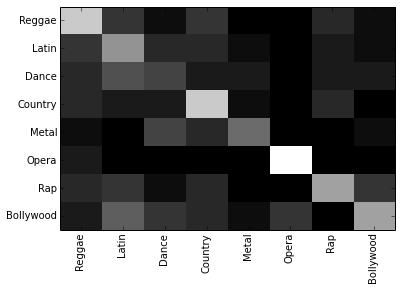

```python
cm = confusion_matrix(features[feature_set]["num_labels"][test_split],
                      predictions)

print cm

fig, ax = plt.subplots()

x = range(len(features[feature_set]["num_to_label"]))
plt.xticks(x,  features[feature_set]["num_to_label"])
plt.yticks(x,  features[feature_set]["num_to_label"])
locs, labels = plt.xticks()
plt.setp(labels, rotation=90)
plt.imshow(cm, aspect='auto',interpolation='nearest', cmap='gray');
```

#### Cross Validation

```python
crossvalidation = StratifiedKFold(features[feature_set]["num_labels"], n_folds=10)

scores = cross_val_score(classifier,
                         features[feature_set]["data"],
                         features[feature_set]["num_labels"],
                         scoring='accuracy',
                         cv=crossvalidation)

print("Accuracy: %0.2f (+/- %0.2f)" % (scores.mean(), scores.std() * 2))
```

```
Accuracy: 0.49 (+/- 0.11)
```

#### Compare performance of all features

Run classification experiments

```python
# classifiers used for evaluation
classifiers = {}

classifiers["GNB"]        = GaussianNB()
classifiers["svm_linear"] = svm.SVC(kernel='linear', C=0.3)
classifiers["knn"]        = KNeighborsClassifier(n_neighbors=1)
classifiers["RF"]         = RandomForestClassifier(n_estimators=10,
                                                   criterion='gini',
                                                   n_jobs=-1)

crossvalidation = StratifiedKFold(features[feature_set]["num_labels"], n_folds=4)

# run k-fold cross-validation
for train, test in crossvalidation:

    for f_name in features.keys():

        features[f_name]["results"] = {}

        # evaluate performance of feature set on each classifier
        for c_name, classifier in classifiers.items():

            if c_name not in features[f_name]["results"]:
                features[f_name]["results"][c_name] = []

            classifier.fit(features[f_name]["data"][train],
                           features[f_name]["num_labels"][train])

            result = classifier.score(features[f_name]["data"][test],
                                      features[f_name]["num_labels"][test])

            features[f_name]["results"][c_name].append( result )
```

Display summary of results measured in mean classification accuracy.

```python
index_labels = []
results_data = []

for df_name in sorted(features.keys()):

    index_labels.append(df_name)

    row_dat = []
    for cf in classifiers.keys():

        vals = features[df_name]["results"][cf]
        row_dat.append(np.mean(vals) * 100)

    results_data.append(row_dat)

warnings.filterwarnings("ignore", category=DeprecationWarning, module="pandas", lineno=570)
pd.DataFrame(np.asarray(results_data), index=index_labels, columns=classifiers.keys())
```

|  | GNB | knn | svm_linear | RF |
| --- | --- | --- | --- | --- |
| mfcc | 49.0 | 48.5 | 53.0 | 45.5 |
| rh | 51.5 | 57.0 | 77.0 | 59.0 |
| rp | 60.0 | 65.0 | 85.0 | 72.0 |
| sc | 26.5 | 28.0 | 31.5 | 35.0 |
| sf | 20.0 | 21.5 | 25.0 | 26.5 |
| sr | 29.0 | 31.5 | 34.0 | 29.5 |
| ssd | 59.5 | 70.5 | 82.5 | 73.0 |
| ssd_rp | 63.0 | 78.0 | 91.0 | 78.0 |
| zcr | 26.0 | 26.5 | 34.5 | 32.5 |

# References

- Thomas Lidy, Andreas Rauber. **Evaluation of Feature Extractors and Psycho-acoustic Transformations for Music Genre Classification.** Proceedings of the Sixth International Conference on Music Information Retrieval (ISMIR 2005), pp. 34-41, London, UK, September 11-15, 2005. [PDF](http://www.ifs.tuwien.ac.at/%7Eandi/publications/pdf/lid_ismir05.pdf)
- A. Rauber, E. Pampalk, D. Merkl. **The SOM-enhanced JukeBox: Organization and Visualization of Music Collections based on Perceptual Models.** In: Journal of New Music Research (JNMR), 32(2):193-210, Swets and Zeitlinger, June 2003. [Abstract](http://www.ifs.tuwien.ac.at/ifs/research/pub_abstracts/rau_jnmr03.txt)
- A. Rauber, and M. Frühwirth. **Automatically Analyzing and Organizing Music Archives.** In: Proceedings of the 5. European Conference on Research and Advanced Technology for Digital Libraries (ECDL 2001), Sept. 4-8 2001, Darmstadt, Germany, Springer Lecture Notes in Computer Science, Springer, 2001. [PDF](http://www.ifs.tuwien.ac.at/ifs/research/pub_pdf/rau_ecdl01.pdf)

# Download

Software for the extraction of Rhythm Patterns, Statistical Spectrum Descriptors, Rhythm Histograms, Modulation Frequency Variance Descriptor, Temporal Statistical Spectrum Descriptors and Temporal Rhythm Histograms is available from the download section.

# Utility Functions

```python
ABBRIVATIONS = {}

# features
ABBRIVATIONS["zcr"] = "Zero Crossing Rate"
ABBRIVATIONS["rms"] = "Root Mean Square"
ABBRIVATIONS["sc"]  = "Spectral Centroid"
ABBRIVATIONS["sf"]  = "Spectral Flux"
ABBRIVATIONS["sr"]  = "Spectral Rolloff"

# aggregations
ABBRIVATIONS["var"] = "Variance"
ABBRIVATIONS["std"] = "Standard Deviation"
ABBRIVATIONS["mean"] = "Average"

PLOT_WIDTH  = 15
PLOT_HEIGHT = 3.5


def show_mono_waveform(samples):

	fig = plt.figure(num=None, figsize=(PLOT_WIDTH, PLOT_HEIGHT), dpi=72, facecolor='w', edgecolor='k')

	channel_1 = fig.add_subplot(111)
	channel_1.set_ylabel('Channel 1')
	#channel_1.set_xlim(0,song_length) # todo
	channel_1.set_ylim(-32768,32768)

	channel_1.plot(samples)

	plt.show();
	plt.clf();

def show_stereo_waveform(samples):

	fig = plt.figure(num=None, figsize=(PLOT_WIDTH, 5), dpi=72, facecolor='w', edgecolor='k')

	channel_1 = fig.add_subplot(211)
	channel_1.set_ylabel('Channel 1')
	#channel_1.set_xlim(0,song_length) # todo
	channel_1.set_ylim(-32768,32768)
	channel_1.plot(samples[:,0])

	channel_2 = fig.add_subplot(212)
	channel_2.set_ylabel('Channel 2')
	channel_2.set_xlabel('Time (s)')
	channel_2.set_ylim(-32768,32768)
	#channel_2.set_xlim(0,song_length) # todo
	channel_2.plot(samples[:,1])

	plt.show();
	plt.clf();


""" short time fourier transform of audio signal """
def stft(sig, frameSize, overlapFac=0.5, window=np.hanning):
    win = window(frameSize)
    hopSize = int(frameSize - np.floor(overlapFac * frameSize))

    # zeros at beginning (thus center of 1st window should be for sample nr. 0)
    samples = np.append(np.zeros(np.floor(frameSize/2.0)), sig)
    # cols for windowing
    cols = np.ceil( (len(samples) - frameSize) / float(hopSize)) + 1
    # zeros at end (thus samples can be fully covered by frames)
    samples = np.append(samples, np.zeros(frameSize))

    frames = stride_tricks.as_strided(samples, shape=(cols, frameSize), strides=(samples.strides[0]*hopSize, samples.strides[0])).copy()
    frames *= win

    return np.fft.rfft(frames)

""" scale frequency axis logarithmically """
def logscale_spec(spec, sr=44100, factor=20.):
    timebins, freqbins = np.shape(spec)

    scale = np.linspace(0, 1, freqbins) ** factor
    scale *= (freqbins-1)/max(scale)
    scale = np.unique(np.round(scale))

    # create spectrogram with new freq bins
    newspec = np.complex128(np.zeros([timebins, len(scale)]))
    for i in range(0, len(scale)):
        if i == len(scale)-1:
            newspec[:,i] = np.sum(spec[:,scale[i]:], axis=1)
        else:
            newspec[:,i] = np.sum(spec[:,scale[i]:scale[i+1]], axis=1)

    # list center freq of bins
    allfreqs = np.abs(np.fft.fftfreq(freqbins*2, 1./sr)[:freqbins+1])
    freqs = []
    for i in range(0, len(scale)):
        if i == len(scale)-1:
            freqs += [np.mean(allfreqs[scale[i]:])]
        else:
            freqs += [np.mean(allfreqs[scale[i]:scale[i+1]])]

    return newspec, freqs

""" plot spectrogram"""
def plotstft(samples, samplerate, binsize=2**10, plotpath=None, colormap="jet", ax=None, fig=None):

    s = stft(samples, binsize)

    sshow, freq = logscale_spec(s, factor=1.0, sr=samplerate)
    ims = 20.*np.log10(np.abs(sshow)/10e-6) # amplitude to decibel

    timebins, freqbins = np.shape(ims)

    if ax is None:
        fig, ax = plt.subplots(1, 1, sharey=True, figsize=(PLOT_WIDTH, 3.5))

    #ax.figure(figsize=(15, 7.5))
    cax = ax.imshow(np.transpose(ims), origin="lower", aspect="auto", cmap=colormap, interpolation="none")
    #cbar = fig.colorbar(cax, ticks=[-1, 0, 1], cax=ax)
    #ax.set_colorbar()

    ax.set_xlabel("time (s)")
    ax.set_ylabel("frequency (hz)")
    ax.set_xlim([0, timebins-1])
    ax.set_ylim([0, freqbins])

    xlocs = np.float32(np.linspace(0, timebins-1, 5))
    ax.set_xticks(xlocs, ["%.02f" % l for l in ((xlocs*len(samples)/timebins)+(0.5*binsize))/samplerate])
    ylocs = np.int16(np.round(np.linspace(0, freqbins-1, 10)))
    ax.set_yticks(ylocs, ["%.02f" % freq[i] for i in ylocs])

    if plotpath:
        plt.savefig(plotpath, bbox_inches="tight")
    else:
        plt.show()

    #plt.clf();
    b = ["%.02f" % l for l in ((xlocs*len(samples)/timebins)+(0.5*binsize))/samplerate]
    return xlocs, b, timebins


def list_audio_samples(sound_files):

	src = ""

	for genre in sound_files.keys():

		src += "<b>" + genre + "</b><br><br>"
		src += "<object width='600' height='90'><param name='movie' value='http://freemusicarchive.org/swf/trackplayer.swf'/><param name='flashvars' value='track=http://freemusicarchive.org/services/playlists/embed/track/{0}.xml'/><param name='allowscriptaccess' value='sameDomain'/><embed type='application/x-shockwave-flash' src='http://freemusicarchive.org/swf/trackplayer.swf' width='600' height='50' flashvars='track=http://freemusicarchive.org/services/playlists/embed/track/{0}.xml' allowscriptaccess='sameDomain' /></object><br><br>".format(sound_files[genre]["online_id"])

	return HTML(src)

def play_sample(sound_files, genre):

	src = "<object width='600' height='90'><param name='movie' value='http://freemusicarchive.org/swf/trackplayer.swf'/><param name='flashvars' value='track=http://freemusicarchive.org/services/playlists/embed/track/{0}.xml'/><param name='allowscriptaccess' value='sameDomain'/><embed type='application/x-shockwave-flash' src='http://freemusicarchive.org/swf/trackplayer.swf' width='600' height='50' flashvars='track=http://freemusicarchive.org/services/playlists/embed/track/{0}.xml' allowscriptaccess='sameDomain' /></object><br><br>".format(sound_files[genre]["online_id"])

	return HTML(src)


def plot_compairison(data, feature, aggregators):

    width = 0.35

    features = {}

    for aggr_name in aggregators:

        features[aggr_name] = []

        for genre in data.keys():

            if aggr_name == "mean":
                features[aggr_name].append(np.mean(data[genre][feature]))
            elif aggr_name == "std":
                features[aggr_name].append(np.std(data[genre][feature]))
            elif aggr_name == "var":
                features[aggr_name].append(np.var(data[genre][feature]))
            elif aggr_name == "median":
                features[aggr_name].append(np.median(data[genre][feature]))
            elif aggr_name == "min":
                features[aggr_name].append(np.min(data[genre][feature]))
            elif aggr_name == "max":
                features[aggr_name].append(np.max(data[genre][feature]))

    fig, ax = plt.subplots()
    ind     = np.arange(len(features[aggregators[0]]))
    rects1  = ax.bar(ind, features[aggregators[0]], 0.7, color='b')
    ax.set_xticklabels( data.keys() )
    ax.set_xticks(ind+width)
    ax.set_ylabel(ABBRIVATIONS[aggregators[0]])
    ax.set_title("{0} Results".format(ABBRIVATIONS[feature]))


    if len(aggregators) == 2:

        ax2 = ax.twinx()
        ax2.set_ylabel(ABBRIVATIONS[aggregators[1]])
        rects2 = ax2.bar(ind+width, features[aggregators[1]], width, color='y')
        ax.legend( (rects1[0], rects2[0]), (ABBRIVATIONS[aggregators[0]], ABBRIVATIONS[aggregators[1]]) )

    plt.show()

def show_feature_superimposed(genre, feature_data, timestamps, squared_wf=False):

    # plot spectrogram
    a,b,c = plotstft(sound_files[genre]["wavedata"], sound_files[genre]["samplerate"]);

    fig = plt.figure(num=None, figsize=(PLOT_WIDTH, PLOT_HEIGHT), dpi=72, facecolor='w', edgecolor='k');
    channel_1 = fig.add_subplot(111);
    channel_1.set_ylabel('Channel 1');
    channel_1.set_xlabel('time');

    # plot waveform
    scaled_wf_y = ((np.arange(0,sound_files[genre]["wavedata"].shape[0]).astype(np.float)) / sound_files[genre]["samplerate"]) * 1000.0

    if squared_wf:
        scaled_wf_x = (sound_files[genre]["wavedata"]**2 / np.max(sound_files[genre]["wavedata"]**2))
    else:
        scaled_wf_x = (sound_files[genre]["wavedata"] / np.max(sound_files[genre]["wavedata"]) / 2.0 ) + 0.5

    #scaled_wf_x = scaled_wf_x**2

    plt.plot(scaled_wf_y, scaled_wf_x, color='lightgrey');

    # plot feature-data
    scaled_fd_y = timestamps * 1000.0
    scaled_fd_x = (feature_data / np.max(feature_data))

    plt.plot(scaled_fd_y, scaled_fd_x, color='r');

    plt.show();
    plt.clf();

def nextpow2(num):
    n = 2
    i = 1
    while n < num:
        n *= 2
        i += 1
    return i

def periodogram(x,win,Fs=None,nfft=1024):

    if Fs == None:
        Fs = 2 * np.pi

    U  = np.dot(win.conj().transpose(), win) # compensates for the power of the window.
    Xx = fft((x * win),nfft) # verified
    P  = Xx*np.conjugate(Xx)/U

    # Compute the 1-sided or 2-sided PSD [Power/freq] or mean-square [Power].
    # Also, compute the corresponding freq vector & freq units.

    # Generate the one-sided spectrum [Power] if so wanted
    if nfft % 2 != 0:
        select = np.arange((nfft+1)/2)  # ODD
        P_unscaled = P[select,:] # Take only [0,pi] or [0,pi)
        P[1:-1] = P[1:-1] * 2 # Only DC is a unique point and doesn't get doubled
    else:
        select = np.arange(nfft/2+1);    # EVEN
        P = P[select]         # Take only [0,pi] or [0,pi) # todo remove?
        P[1:-2] = P[1:-2] * 2

    P = P / (2* np.pi)

    return P

def map_labels_to_numbers(eval_data):

    for df_name in eval_data.keys():

        # create label mapping
        label_mapping = {}
        num_to_label  = []

        i = 0
        for l in set(eval_data[df_name]["labels"]):
            label_mapping[l] = i
            num_to_label.append(l)
            i += 1

        eval_data[df_name]["label_mapping"] = label_mapping
        eval_data[df_name]["num_to_label"] = num_to_label

        mapped_labels = []

        for i in range(eval_data[df_name]["labels"].shape[0]):
            #print label_mapping[ls[i]]
            mapped_labels.append(label_mapping[eval_data[df_name]["labels"][i]])

        #transformed_label_space.append(mapped_labels)

        eval_data[df_name]["num_labels"] = np.asarray(mapped_labels)

styles = "<style>div.cell{ width:900px; margin-left:0%; margin-right:auto;} </style>"
HTML(styles)
```